# Using factR

# 1 Introduction

High throughput RNA sequencing experiments have allowed the discovery of many new RNA species. Current bioinformatic pipelines typically involve aligning these sequencing reads to the genome and assembling contiguous reads into transcript architectures. This will output full descriptions of transcript and exon coordinates in Gene Transfer Format (GTF). Further analyses including differential transcript expression can be performed with these custom-assembled transcript information. Despite having rich details on transcript architectures, these custom-assembled transcripts lack functional information including coding potential.

To this end, we developed a program with tools to Functionally Annotate Custom-assembled Transcripts in R (*factR*). At its core, *factR* will construct CDS features for assembled transcriptomes using a reference annotation as guide. With this newly-built coding information, we may then query transcripts for protein domain features, for nonsense-mediated decay inducing features and for upstream open-reading frames. *factR* also contain tools to annotate alternative segments between transcripts, to auto-fill gene metadata and other tools to visualize particular transcript families from a GTF file.

# 2 Getting started

To run the code examples shown in this vignette, we need to load the following packages:

```r
library(factR)
library(AnnotationHub)
library(Biostrings)
library(BSgenome.Mmusculus.UCSC.mm10)
library(GenomicFeatures)
library(rtracklayer)
```

## 2.1 How to install

To install *factR*, open R and type:

```r
install.packages("devtools")
devtools::install_github("fursham-h/factR")
```

## 2.2 What you need

### 2.2.1 Query transcript assembly

Transcript assembly programs typically outputs a GTF file containing transcript and exon coordinates, as well as attributes for each entry. It is mandatory that your assembly contain **gene_id** and **transcript_id** attributes.

Query GTF file have to be imported into R and parsed into a GenomicRanges object. To do so, run:

```r
# import gtf file using rtracklayer
query_gtf <- import('path/to/your.gtf')
```

### 2.2.2 Reference annotation

Reference transcript annotation serves as a guide in the construction of query CDS. We strongly recommend using transcript annotation in GTF/GFF3 format for the workflow. Reference GTF annotation can be acquired from the Annotation Hub database in R or downloaded locally from data server website via FTP. For the latter, the GTF file have to be imported into R and parsed into a GenomicRanges object.

Here, we will describe three ways to obtain mouse GRCm38 annotation:

1. Gencode annotation from Annotation Hub database

```r
# query database for mouse gencode basic annotation
ah <- AnnotationHub()
query(ah, c('Mus musculus', 'gencode', 'gff', 'basic'))
```

```
#> AnnotationHub with 2 records
#> # snapshotDate(): 2019-05-02
#> # $dataprovider: Gencode
#> # $species: Mus musculus
#> # $rdataclass: GRanges
#> # additional mcols(): taxonomyid, genome, description, coordinate_1_based, maintainer,
#> #   rdatadateadded, preparerclass, tags, rdatapath, sourceurl, sourcetype
#> # retrieve records with, e.g., 'object[["AH49547"]]'
#>
#>             title
#>   AH49547 | gencode.vM6.basic.annotation.gff3.gz
#>   AH49549 | gencode.vM6.chr_patch_hapl_scaff.basic.annotation.gff3.gz
```

```
#>  retrieve id 'AH49547'
```

```r
ref_gtf <- ah[['AH49547']]
```

2. Ensembl annotation from Annotation Hub database

```r
# Load annotation hub and query database for ensembl annotation as in method 1 above.

# retrieve latest GRCm38 annotation from ensembl
ref_gtf <- ah[['AH60127']]
```

3. Import locally downloaded GTF annotation into R

```r
# import reference gtf file
query_gtf <- import('path/to/reference.gtf')
```

### 2.2.3 Genomic sequence

Genomic DNA sequence is required for determining open-reading frames and for *in silico* translation of query transcripts. Here, we describe three ways to obtain genomic sequence for mouse GRCm38 assembly:

1. BSgenome sequence object from UCSC

```r
# install GRCm38 sequence object and rename for convenience
BiocManager::install("BSgenome.Mmusculus.UCSC.mm10")
library(BSgenome.Mmusculus.UCSC.mm10)
Mmusculus <- BSgenome.Mmusculus.UCSC.mm10
```

2. TwoBit fasta sequence from Annotation Hub

```r
# query database for mouse gencode basic annotation
ah <- AnnotationHub()
query(ah, c("Mus musculus", "release-91", 'fasta', 'GRCm38'))
```

```
#> AnnotationHub with 5 records
#> # snapshotDate(): 2019-05-02
#> # $dataprovider: Ensembl
#> # $species: Mus musculus
#> # $rdataclass: TwoBitFile
#> # additional mcols(): taxonomyid, genome, description, coordinate_1_based, maintainer,
#> #   rdatadateadded, preparerclass, tags, rdatapath, sourceurl, sourcetype
#> # retrieve records with, e.g., 'object[["AH60491"]]'
#>
#>             title
#>   AH60491 | Mus_musculus.GRCm38.cdna.all.2bit
#>   AH60492 | Mus_musculus.GRCm38.dna.primary_assembly.2bit
#>   AH60493 | Mus_musculus.GRCm38.dna_rm.primary_assembly.2bit
#>   AH60494 | Mus_musculus.GRCm38.dna_sm.primary_assembly.2bit
#>   AH60495 | Mus_musculus.GRCm38.ncrna.2bit
```

```
#>  retrieve id 'AH60492'
```

```r
Mmusculus <- ah[['AH60492']]
```

3. Import local FASTA genome sequence file

```r
# load package and import fasta file as a DNAStringSet
Mmusculus <- readDNAStringSet('path/to/fasta')
```

Note: when using DNA FASTA from Ensembl, do check header lines for entry names. If long names are given (eg. 1 dna:chromosome chromosome:GRCm38:1:1:195471971:1 REF), you would need to convert them to short names in order to have consistent sequence levels. This can be done by running the following:

```r
# load package and import fasta file as a DNAStringSet
library(purrr)
library(stringr)
names(Mmusculus) <- str_split(seqlevels(Mmusculus), " ") %>% map_chr(`[`, 1)
```

# 3 Sample datasets

## 3.1 Query

*factR* package contains a sample assembled GTF imported as a GRanges object. The assembly was constructed from a mouse dataset and contain **transcript** and **exon** descriptions of 4 transcript isoforms from the same parent gene. Transcripts in **query_gtf** have been assigned generic **gene_ids** and **transcript_ids**. This is to recapitulate the nomenclature of a typical custom-assembled GTF.

```r
# inspect query object
head(query_gtf)
```

```
#> GRanges object with 6 ranges and 3 metadata columns:
#>       seqnames            ranges strand |       type transcript_id     gene_id
#>          <Rle>         <IRanges>  <Rle> |   <factor>   <character> <character>
#>   [1]       10 79854427-79864432      + | transcript   transcript1       GeneA
#>   [2]       10 79854427-79854721      + |       exon   transcript1       GeneA
#>   [3]       10 79856504-79856534      + |       exon   transcript1       GeneA
#>   [4]       10 79858752-79858824      + |       exon   transcript1       GeneA
#>   [5]       10 79858952-79859271      + |       exon   transcript1       GeneA
#>   [6]       10 79859352-79859522      + |       exon   transcript1       GeneA
#>   -------
#>   seqinfo: 1 sequence from an unspecified genome; no seqlengths
```

```r
# list out transcript_id and gene_id names
unique(query_gtf$transcript_id)
```

```
#> [1] "transcript1" "transcript2" "transcript3" "transcript4"
```

```r
unique(query_gtf$gene_id)
```

```
#> [1] "GeneA"
```

Users can quickly visualize the exon structure of these query transcripts using the `plotGTFtranscripts` tool, which is essentially a convenient wrapper to plot transcripts using the *wiggleplotr* package:

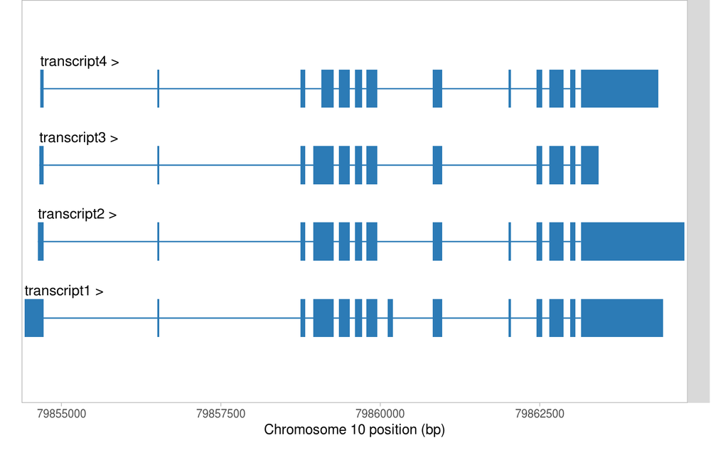

```r
plotGTFtranscripts(query_gtf)
```

## 3.2 Reference

For our reference annotation, we will be using a subset of GRCm38 gencode reference annotation which contain basic transcripts from the same gene family as our query gene.

```r
# inspect reference object
head(ref_gtf)
```

```
#> GRanges object with 6 ranges and 5 metadata columns:
#>       seqnames            ranges strand |        type     phase               gene_id   gene_name        transcript_id
#>          <Rle>         <IRanges>  <Rle> |    <factor> <integer>           <character> <character>          <character>
#>   [1]    chr10 79854427-79864432      + |  transcript      <NA> ENSMUSG00000006498.14       Ptbp1 ENSMUST00000172282.5
#>   [2]    chr10 79854427-79854721      + |        exon      <NA> ENSMUSG00000006498.14       Ptbp1 ENSMUST00000172282.5
#>   [3]    chr10 79854714-79854721      + |         CDS         0 ENSMUSG00000006498.14       Ptbp1 ENSMUST00000172282.5
#>   [4]    chr10 79854714-79854716      + | start_codon         0 ENSMUSG00000006498.14       Ptbp1 ENSMUST00000172282.5
#>   [5]    chr10 79856504-79856534      + |        exon      <NA> ENSMUSG00000006498.14       Ptbp1 ENSMUST00000172282.5
#>   [6]    chr10 79856504-79856534      + |         CDS         1 ENSMUSG00000006498.14       Ptbp1 ENSMUST00000172282.5
#>   -------
#>   seqinfo: 1 sequence from an unspecified genome; no seqlengths
```

```r
# list out transcript_id and gene_id names
unique(ref_gtf$transcript_id)
```

```
#> [1] "ENSMUST00000172282.5" "ENSMUST00000165704.5"
```

```r
unique(ref_gtf$gene_id)
```

```
#> [1] "ENSMUSG00000006498.14"
```

# 4 Matching chromosome IDs

Different genomic objects may have different chromosome IDs (aka seqlevels), depending on its source. Users may have a custom GTF with “Ensembl”-style seqlevels but wish to use a gencode reference annotation which contain “UCSC”-style seqlevels. The sample **query_gtf** and **ref_gtf** objects presents this exact predicament:

```r
seqlevelsStyle(query_gtf)
```

```
#> [1] "NCBI"    "Ensembl" "MSU6"    "JGI2.F"  "AGPvF"
```

```r
seqlevelsStyle(ref_gtf)
```

```
#> [1] "UCSC"
```

*factR* contain a tool to effectively match the seqlevels of a query GRanges object to any reference object with seqlevel information:

```r
# matching seqlevels
matched_query_gtf <- matchSeqLevels(query_gtf, Mmusculus)

head(matched_query_gtf)
```

```
#> GRanges object with 6 ranges and 3 metadata columns:
#>       seqnames            ranges strand |       type transcript_id     gene_id
#>          <Rle>         <IRanges>  <Rle> |   <factor>   <character> <character>
#>   [1]    chr10 79854427-79864432      + | transcript   transcript1       GeneA
#>   [2]    chr10 79854427-79854721      + |       exon   transcript1       GeneA
#>   [3]    chr10 79856504-79856534      + |       exon   transcript1       GeneA
#>   [4]    chr10 79858752-79858824      + |       exon   transcript1       GeneA
#>   [5]    chr10 79858952-79859271      + |       exon   transcript1       GeneA
#>   [6]    chr10 79859352-79859522      + |       exon   transcript1       GeneA
#>   -------
#>   seqinfo: 1 sequence from an unspecified genome; no seqlengths
```

Note: `matchSeqLevels` will drop any unmatched seqlevels from query

*factR* also comes with the function `has_consistentSeqlevels` to test if two or more objects have consistent seqlevels. This function returns a logical value of FALSE if input objects have inconsistent seqlevels and recommends a `matchSeqLevels` function to run.

```r
has_consistentSeqlevels(query_gtf, ref_gtf)
has_consistentSeqlevels(matched_query_gtf, ref_gtf)
```

[output not shown]

```
#> [1] TRUE
```

# 5 Matching gene metadata

Custom-built GTF annotation may contain generic **gene_id** and **gene_name** metadata (e.g. ‘MSTRG1’), depending on how it was constructed. Users who wish to fill these metadata using a reference annotation may run the `matchGeneMeta` function:

```r
# matching gene metadata
matched_query_gtf <- matchGeneMeta(matched_query_gtf, ref_gtf)
```

```
#> Number of mismatched gene_ids found: 1
#> ---> Attempting to match gene_ids by finding overlapping coordinates...
#> ---> 1 gene_id matched
#> Total gene_ids corrected: 1
#> Remaining number of mismatched gene_ids: 0
```

```r
head(matched_query_gtf)
```

```
#> GRanges object with 6 ranges and 6 metadata columns:
#>       seqnames            ranges strand |       type transcript_id               gene_id old_gene_id match_level   gene_name
#>          <Rle>         <IRanges>  <Rle> |   <factor>   <character>           <character> <character>   <numeric> <character>
#>   [1]    chr10 79854427-79864432      + | transcript   transcript1 ENSMUSG00000006498.14       GeneA           4       Ptbp1
#>   [2]    chr10 79854427-79854721      + |       exon   transcript1 ENSMUSG00000006498.14       GeneA           4       Ptbp1
#>   [3]    chr10 79856504-79856534      + |       exon   transcript1 ENSMUSG00000006498.14       GeneA           4       Ptbp1
#>   [4]    chr10 79858752-79858824      + |       exon   transcript1 ENSMUSG00000006498.14       GeneA           4       Ptbp1
#>   [5]    chr10 79858952-79859271      + |       exon   transcript1 ENSMUSG00000006498.14       GeneA           4       Ptbp1
#>   [6]    chr10 79859352-79859522      + |       exon   transcript1 ENSMUSG00000006498.14       GeneA           4       Ptbp1
#>   -------
#>   seqinfo: 1 sequence from an unspecified genome; no seqlengths
```

By default, this function will match query transcripts to reference by overlapping coordinates. Users may improve the accuracy of this matching function by providing values to **primary_gene_id** and **secondary_gene_id** arguments. See ?matchGeneMeta for detailed description.

# 6 Construct query CDS information

To build CDS information on our query data, users can simply run:

```r
new_query_gtf <- buildCDS(matched_query_gtf, ref_gtf, Mmusculus)
```

```
#> Out of 4 transcripts in `matched_query_gtf`, 4 transcript CDSs were built
```

The above function will return a new GRanges object containing exon entries from **query_gtf** with appended cds entries. User can inspect the contents of the object further.

```r
# check lengths of input and output GRanges
length(query_gtf)
```

```
#> [1] 56
```

```r
length(new_query_gtf)
```

```
#> [1] 105
```

```r
# inspect CDS entries
head(new_query_gtf[mcols(new_query_gtf)$type == "CDS"])
```

```
#> GRanges object with 6 ranges and 8 metadata columns:
#>       seqnames            ranges strand |     type transcript_id     gene_id old_gene_id match_level   gene_name     phase    built_from
#>          <Rle>         <IRanges>  <Rle> | <factor>   <character> <character> <character>   <numeric> <character> <numeric>   <character>
#>   [1]    chr10 79854714-79854721      + |      CDS   transcript1        <NA>        <NA>        <NA>        <NA>         0 Full coverage
#>   [2]    chr10 79856504-79856534      + |      CDS   transcript1        <NA>        <NA>        <NA>        <NA>         1 Full coverage
#>   [3]    chr10 79858752-79858824      + |      CDS   transcript1        <NA>        <NA>        <NA>        <NA>         0 Full coverage
#>   [4]    chr10 79858952-79859271      + |      CDS   transcript1        <NA>        <NA>        <NA>        <NA>         2 Full coverage
#>   [5]    chr10 79859352-79859522      + |      CDS   transcript1        <NA>        <NA>        <NA>        <NA>         0 Full coverage
#>   [6]    chr10 79859602-79859712      + |      CDS   transcript1        <NA>        <NA>        <NA>        <NA>         0 Full coverage
#>   -------
#>   seqinfo: 1 sequence from an unspecified genome; no seqlengths
```

User can visualize the coding structure of each transcripts using the `plotGTFtranscripts` tool, which is essentially a convenient wrapper to plot transcripts using the *wiggleplotr* package:

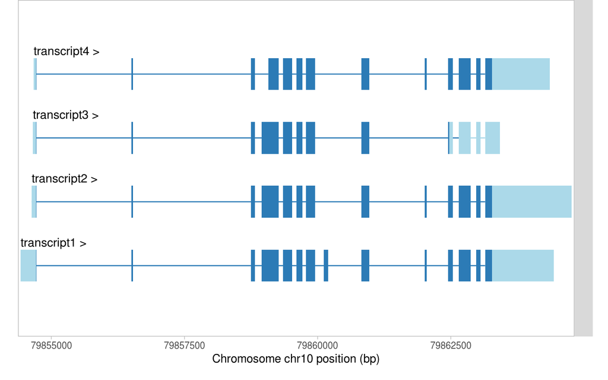

```r
plotGTFtranscripts(new_query_gtf)
```

The new query GTF Granges object can be exported as a .gtf file using *rtracklayer*’s export funcition:

```r
# get GrangesList of query exons and cds
rtracklayer::export(new_query_gtf, 'path/to/output.gtf', format = 'gtf')
```

# 7 Extracting protein features on coding transcripts

Upon construction of coding segments on transcripts, users may be interested in determining the functional domains which is encoded within the coding sequence. To this end, users can utilize the `extractCDSfeature` function. This tool accepts a GTF GRanges object containing CDS information as input, together with a genome sequence object. After checking the translated protein sequence, `extractCDSfeature` will query the SuperFamily database for domain features by calling out the `hmmer` function from *bio3d* package. The function will output 3 output fields: **desc**, **evalue** and **nincluded**.

```r
extractCDSfeature(new_query_gtf, Mmusculus)
```

```
#> # A tibble: 4 x 4
#>   id          hmmer.desc              hmmer.evalue hmmer.nincluded
#>   <chr>       <chr>                          <dbl>           <dbl>
#> 1 transcript1 RNA-binding domain, RBD     2.80e-81               4
#> 2 transcript2 RNA-binding domain, RBD     2.10e-81               4
#> 3 transcript3 RNA-binding domain, RBD     1.30e-43               2
#> 4 transcript4 RNA-binding domain, RBD     1.20e-72               4
```

More fields from the `hmmer` function can be requested by providing a list of output fields to the hmmer argument:

```r
extractCDSfeature(new_query_gtf, Mmusculus, hmmer = c('default', 'bitscore', 'pvalue'))
```

```
#> # A tibble: 4 x 6
#>   id          hmmer.desc              hmmer.evalue hmmer.nincluded hmmer.bitscore hmmer.pvalue
#>   <chr>       <chr>                          <dbl>           <dbl>          <dbl>        <dbl>
#> 1 transcript1 RNA-binding domain, RBD     2.80e-81               4           266.        -195.
#> 2 transcript2 RNA-binding domain, RBD     2.10e-81               4           267.        -195.
#> 3 transcript3 RNA-binding domain, RBD     1.30e-43               2           146.        -108.
#> 4 transcript4 RNA-binding domain, RBD     1.20e-72               4           239         -175.
```

This tool also currently support the identification of signal peptide by running the `signalHsmm` function from the *signalHsmm* package. This feature is not run by default, but can be initiated by setting the argument for **signalHsmm** to ‘default’ or any one of the supported output fields. Users can skip testing of any of these featyres by setting the **hmmer** or **signalHsmm** arguments to NULL

```r
extractCDSfeature(new_query_gtf, Mmusculus, hmmer = NULL, signalHsmm = 'default')
```

```
#> # A tibble: 4 x 2
#>   id          signalHsmm.sp_probability
#>   <chr>       <chr>
#> 1 transcript1 0.000574583738246925
#> 2 transcript2 0.000574583738246925
#> 3 transcript3 0.000574583738246925
#> 4 transcript4 0.000574583738246925
```

In order to extract the domain features, `extractCDSfeature` will attempt to submit the protein coding sequence to the SuperFamily database and return a summary of the domain structure. As this process is done over HTTP, the speed of this function is greatly dependent on the server and on the number of CDS in your list. This process can be sped up by subsetting the list of transcripts for analysis by providing logical conditions to the **…** argument. This argument accepts unquoted metadata column names from the GTF as variables and quoted values to filter the GTF by. For example:

[output not shown]

# 8 Predicting NMD-inducing features on coding transcripts

Coding RNAs harbouring a premature stop codon are potentially eliminated by a process called Nonsense-mediated decay (NMD). Two common features of NMD targets include the upstream position of its stop_codon relative to the last exon-exon junction and the extensive length of its 3’-untranslated region (3’UTR). To report these NMD features and predict if any of the transcripts in the custom annotation are NMD-sensitive, users can run the `predictNMD` tool.

`predictNMD` can accept a GTF GRanges object as input and will only analyze coding transcripts for NMD-features.

```r
predictNMD(new_query_gtf)
```

```
#> # A tibble: 4 x 6
#>   transcript  stop_to_lastEJ num_of_downEJs stop_to_downEJs threeUTRlength is_NMD
#>   <chr>                <dbl>          <int> <chr>                    <dbl> <lgl>
#> 1 transcript1           -130              0 ""                        1158 FALSE
#> 2 transcript2           -130              0 ""                        1497 FALSE
#> 3 transcript3            364              3 "69,286,364"               644 TRUE
#> 4 transcript4           -130              0 ""                        1085 FALSE
```

`predictNMD` will output a tibble dataframe with report on NMD-inducing feature for each coding transcript. The column **stop_to_lastEJ** describes the relative distance of the stop_codon to the last exon-exon junction (lastEJ) of each transcript. Thus, a positive integer means that the lastEJ is downstream of the stop_codon. `predictNMD` also returns the number of exon-junctions downstream of the stop_codon (**num_of_downEJs**) and the relative distance of the stop_codon to each downstream exon-junctions (**stop_to_downEJs**). **threeUTRlength** describes the length of the 3’-untranslated region for each coding transcript. The column containing logical values for **is_NMD** will return TRUE if the **stop_to_lastEJ** value exceed the NMD triggering threshold which is typically 50 base-pair. Users may set a custom value by overriding the default **NMD_threshold** argument.

Users who wish to analyze certain genes or transcripts in their GTF GRanges for NMD features may provide logical conditions to the `...` argument to subset their GTF input. This argument accepts unquoted metadata column names from the GTF as variables and quoted values to filter the GTF by. For example:

```r
predictNMD(new_query_gtf, transcript_id == 'transcript3')
```

[output not shown]

This feature provides user the flexibility to analyze desired genes/transcripts from a large collection of GTF GRanges. Input GTF can be filtered with multiple conditions as long as variable names are found in the input GRanges object. Here are some examples on how this feature can be used on an Ensembl GTF annotation:

```r
# retrieve latest GRCm38 annotation from ensembl
ah <- AnnotationHub()
mm10_gtf <- ah[['AH60127']]

# predict transcripts from Ptbp1 gene for NMD features
predictNMD(mm10_gtf, gene_name == 'Ptbp1')
```

```
#> # A tibble: 9 x 6
#>   transcript         stop_to_lastEJ num_of_downEJs stop_to_downEJs threeUTRlength is_NMD
#>   <chr>                       <dbl>          <int> <chr>                    <dbl> <lgl>
#> 1 ENSMUST00000057343            364              3 "69,286,364"               644 TRUE
#> 2 ENSMUST00000095457           -130              0 ""                        1085 FALSE
#> 3 ENSMUST00000165704           -130              0 ""                        1497 FALSE
#> 4 ENSMUST00000165724            286              2 "69,286"                   362 TRUE
#> 5 ENSMUST00000168683           -145              0 ""                           0 FALSE
#> 6 ENSMUST00000169091            -36              0 ""                           0 FALSE
#> 7 ENSMUST00000169483            139              1 "139"                      152 TRUE
#> 8 ENSMUST00000171599            -63              0 ""                           0 FALSE
#> 9 ENSMUST00000172282           -130              0 ""                        1158 FALSE
#> Warning message:
#> 7 transcript(s) have missing cds info and was not analyzed
```

```r
# predict several transcripts from Ptbp1 gene for NMD features
predictNMD(mm10_gtf, gene_name == 'Ptbp1', transcript_id == c('ENSMUST00000057343', 'ENSMUST00000095457'))
```

```
#> # A tibble: 2 x 6
#>   transcript         stop_to_lastEJ num_of_downEJs stop_to_downEJs threeUTRlength is_NMD
#>   <chr>                       <dbl>          <int> <chr>                    <dbl> <lgl>
#> 1 ENSMUST00000057343            364              3 "69,286,364"               644 TRUE
#> 2 ENSMUST00000095457           -130              0 ""                        1085 FALSE
```